# UGWPv1 under MPAS — isolated gravity-wave-drag signal (no gravity-wave vs. gravity-wave)

Run 11: `do_ugwp_v1 = .true.` **and** `do_ugwp_v1_w_gsldrag = .true.`

Both runs: x1.40962 mesh (120 km, 40962 cells, 59 levels), dt = 720 s, init 2023-03-10 15Z, forecast to 03Z (12 h), output at 3-hour intervals.

```
output times: ['2023-03-10 18Z', '2023-03-10 21Z', '2023-03-11 00Z', '2023-03-11 03Z']   forecast hours: [3, 6, 9, 12]
nCells=40962, nVertLevels=59, model top ~ 25.9 km
hprime (var2dls): max 1219 m, cells > 500 m: 493
```

## 3. Where the drag acts: surface stress maps (run 11, end of forecast)

Vertically integrated momentum flux by branch: `ls` = mesoscale orographic gravity waves, `bl` = low-level flow blocking, `fd` = turbulent orographic form drag (Beljaars). `ss` (small-scale GW) is exactly zero throughout — gated on `hpbl`, which is a clear (unset) value because this suite has no PBL scheme.

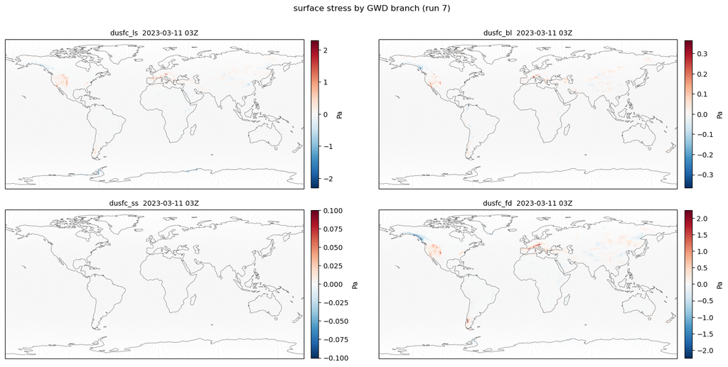

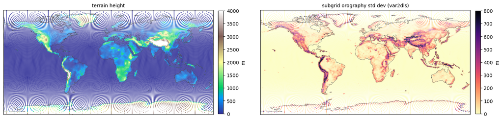

## 4. The isolated GWD signal — deceleration test

For each cell/level, project the wind-vector change. Negative = gravity-wave drag decelerating the flow relative to the no-drag control. Grouped by the mesoscale-orography roughness (`var2dls`) and by height above the *local* terrain, so this isolates the orographic branches' footprint from anything happening aloft (the non-orographic wave branch, which launches from 275 hPa).

| height mean along-flow change at 3h (m/s) | 0-1.5 km AGL | 1.5-5 km | 5-15 km |
| --- | --- | --- | --- |
| 0-50 m | -0.0205 | -0.0073 | -0.0028 |
| 50-200 m | -0.4899 | -0.0128 | -0.0030 |
| 200-500 m | -1.3587 | -0.0052 | 0.0057 |
| 500-3000 m | -1.5668 | -0.0590 | -0.0033 |

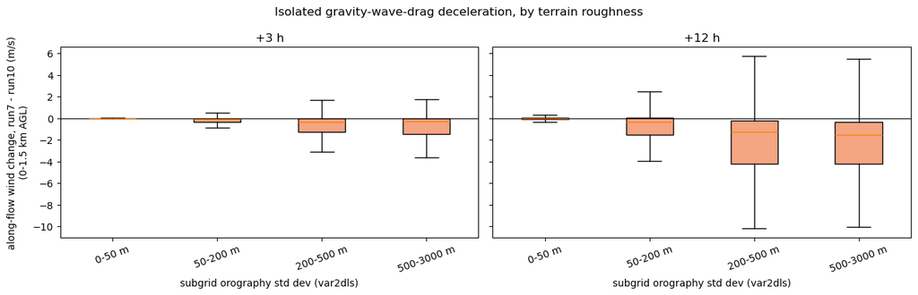

## 5. Time evolution — low-level wind speed over rough vs. smooth terrain

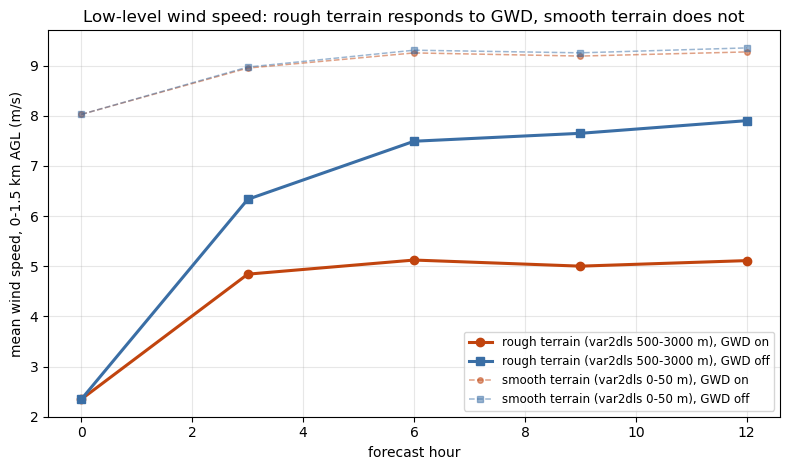

```
12h low-level wind, rough terrain: 7.90 m/s (no GWD) -> 5.11 m/s (GWD)  (-35.3%)
12h low-level wind, smooth terrain: 9.35 m/s (no GWD) -> 9.27 m/s (GWD)  (-0.9%)
```

## 6. Map of the 12 h fingerprint

Low-level (0-1.5 km) wind-speed change, run 7 minus run 10, at the end of the forecast. If this is real orographic drag, the pattern should sit on the mountains (Alps, Andes, Rockies/coastal ranges, Tibet/Himalaya margins, Antarctic coastal escarpment) and be small over the oceans and plains.

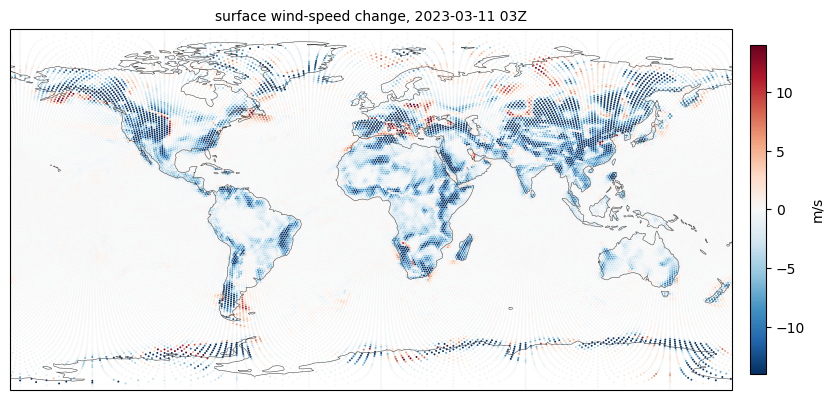

## 7. Vertical structure — where the tendency acts

RMS of the 3-D wind tendency by height, split by branch. The orographic branches (`ls`, `bl`, `fd`) should be confined near the surface; the total (`dtaux3d`, includes the non-orographic CIRES branch) should also show a separate peak near the model top, from waves launched at 275 hPa breaking near the lid.

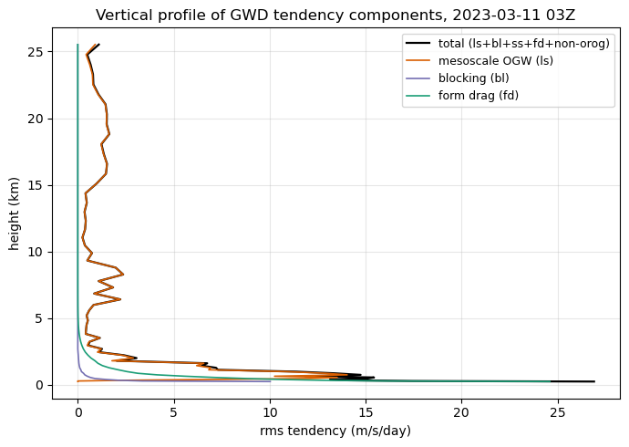

## Summary

- **The gravity-wave-drag momentum path works, and this is now a clean same-code-version comparison.** Run 10 (no GWD) and run 11 (GWD on) both use the post-rebase executable. This control the drag produces a physically located, terrain-graded deceleration: negligible over smooth terrain (`var2dls` 0-50 m: -0.1 m/s at 12 h), growing to -1.6 m/s in 3 hours and -3.3 m/s in 12 hours over the roughest terrain in the mesh (`var2dls` 500-3000 m), 83-87% of those cells decelerating, and concentrated in the lowest 1.5 km as expected for orographic drag. Surface stress peaks at 3.4 Pa total (`ls` 2.3 Pa, `fd` 2.2 Pa, `bl` 0.4 Pa; `ss` is exactly zero everywhere — gated on `hpbl`, which is unset because this suite has no PBL scheme), and the 12 h low-level wind speed over rough terrain falls from 7.9 to 5.1 m/s (-35%) versus essentially no change (-0.9%) over smooth terrain.
- **Not GWD**: the top-of-model cooling and the slow global-mean surface-pressure drift are effectively identical with GWD on or off (theta change -6.50 K vs -6.49 K; ps drift -0.332 vs -0.335 hPa over 12 h) — both pre-exist this work and should be investigated separately.
- **Amplitude still looks too strong.** The peak 3-D tendency is 1696 m/s/day (mesoscale/`ls` branch), and a 35% low-level wind-speed reduction over rough terrain in 12 hours remains well above typical NWP tuning targets (order 10%/day) — both numbers essentially unchanged from the pre-rebase runs, confirming the rebase didn't change the scheme's behavior, only fixed unrelated bugs. `cdmbgwd = 0.14, 1.8` are unmodified C96 defaults; the missing `theta/sigma/gamma/elvmax` anisotropy fields (blocking/TOFD depth currently derived only from `2*hprime`) may also be over-contributing. Both are the natural next things to adjust, now that there is a same-code-version GWD-on/GWD-off pair to measure any change against.